# Insights and visualization only

```python
import os
import pandas as pd
import numpy as np
```

```python
from google.colab import drive
drive.mount('/content/drive')
```

```python
pwd
```

```
'/content'
```

```python
os.chdir("/content/drive/My Drive/voconic_labs")
```

```python
covid_confirmed=pd.read_csv("/content/drive/My Drive/voconic_labs/covid_confirmed_data.csv",na_values=["?",",","#","unknown"])
```

```python
covid_deaths=pd.read_csv("/content/drive/My Drive/voconic_labs/covid_deaths.csv",na_values=["?",",","#","unknown"])
```

```python
covid_recovered=pd.read_csv("/content/drive/My Drive/voconic_labs/covid_recovered_data.csv",na_values=["?",",","#","unknown"])
```

```python
countrywise_data=pd.read_csv("/content/drive/My Drive/voconic_labs/csse_daily.csv",na_values=["?",",","#","unknown"])
```

```python
us_data_alone=pd.read_csv("/content/drive/My Drive/voconic_labs/07-12-2020.csv",na_values=["?",",","#","unknown"])
```

```python
covid_confirmed.head()
```

|  | Country/Region | Province/State | Date | confirmed |
| --- | --- | --- | --- | --- |
| 0 | Afghanistan | NaN | 1/22/20 | 0 |
| 1 | Afghanistan | NaN | 1/23/20 | 0 |
| 2 | Afghanistan | NaN | 1/24/20 | 0 |
| 3 | Afghanistan | NaN | 1/25/20 | 0 |
| 4 | Afghanistan | NaN | 1/26/20 | 0 |

```python
list(covid_confirmed['Province/State'].unique())
```

```
[nan,
 'Australian Capital Territory',
 'New South Wales',
 'Northern Territory',
 'Queensland',
 'South Australia',
 'Tasmania',
 'Victoria',
 'Western Australia',
 'Alberta',
 'British Columbia',
 'Diamond Princess',
 'Grand Princess',
 'Manitoba',
 'New Brunswick',
 'Newfoundland and Labrador',
 'Northwest Territories',
 'Nova Scotia',
 'Ontario',
 'Prince Edward Island',
 'Quebec',
 'Saskatchewan',
 'Yukon',
 'Anhui',
 'Beijing',
 'Chongqing',
 'Fujian',
 'Gansu',
 'Guangdong',
 'Guangxi',
 'Guizhou',
 'Hainan',
 'Hebei',
 'Heilongjiang',
 'Henan',
 'Hong Kong',
 'Hubei',
 'Hunan',
 'Inner Mongolia',
 'Jiangsu',
```

[output cut: 27 more lines]

```
 'St Martin',
 'Aruba',
 'Bonaire, Sint Eustatius and Saba',
 'Curacao',
 'Sint Maarten',
 'Anguilla',
 'Bermuda',
 'British Virgin Islands',
 'Cayman Islands',
 'Channel Islands',
 'Falkland Islands (Malvinas)',
 'Gibraltar',
 'Isle of Man',
 'Montserrat',
 'Turks and Caicos Islands']
```

```python
covid_confirmed.shape
```

```
(46284, 4)
```

```python
covid_confirmed.describe()
```

|  | confirmed |
| --- | --- |
| count | 4.628400e+04 |
| mean | 1.337838e+04 |
| std | 1.013850e+05 |
| min | 0.000000e+00 |
| 25% | 1.000000e+00 |
| 50% | 1.300000e+02 |
| 75% | 1.184250e+03 |
| max | 3.364157e+06 |

```python
covid_confirmed.isnull().sum()
```

```
Country/Region        0
Province/State    32190
Date                  0
confirmed             0
dtype: int64
```

```python
covid_deaths.head()
```

|  | Country/Region | Province/State | Date | Deaths |
| --- | --- | --- | --- | --- |
| 0 | Afghanistan | NaN | 1/22/20 | 0 |
| 1 | Afghanistan | NaN | 1/23/20 | 0 |
| 2 | Afghanistan | NaN | 1/24/20 | 0 |
| 3 | Afghanistan | NaN | 1/25/20 | 0 |
| 4 | Afghanistan | NaN | 1/26/20 | 0 |

```python
covid_deaths.shape
```

```
(46284, 4)
```

```python
covid_recovered.head()
```

|  | Country/Region | Province/State | Column | Value |
| --- | --- | --- | --- | --- |
| 0 | Afghanistan | NaN | 1/22/20 | 0 |
| 1 | Afghanistan | NaN | 1/23/20 | 0 |
| 2 | Afghanistan | NaN | 1/24/20 | 0 |
| 3 | Afghanistan | NaN | 1/25/20 | 0 |
| 4 | Afghanistan | NaN | 1/26/20 | 0 |

```python
covid_recovered.rename(columns = {'Column':'Date'}, inplace = True)
covid_recovered.rename(columns = {'Value':'Recovered'}, inplace = True)
```

```python
covid_confirmed.head()
```

|  | Country/Region | Province/State | Date | confirmed |
| --- | --- | --- | --- | --- |
| 0 | Afghanistan | NaN | 1/22/20 | 0 |
| 1 | Afghanistan | NaN | 1/23/20 | 0 |
| 2 | Afghanistan | NaN | 1/24/20 | 0 |
| 3 | Afghanistan | NaN | 1/25/20 | 0 |
| 4 | Afghanistan | NaN | 1/26/20 | 0 |

```python
covid_recovered.isnull().sum()
```

```
Country/Region        0
Province/State    32364
Date                  0
Recovered             0
dtype: int64
```

```python
covid_recovered.describe()
```

|  | Recovered |
| --- | --- |
| count | 4.402200e+04 |
| mean | 6.270775e+03 |
| std | 4.082316e+04 |
| min | 0.000000e+00 |
| 25% | 0.000000e+00 |
| 50% | 3.100000e+01 |
| 75% | 6.100000e+02 |
| max | 1.291251e+06 |

```python
covid_recovered.shape
```

```
(44022, 4)
```

```python
us_data_alone.tail()
```

|  | Province_State | Country_Region | Last_Update | Lat | Long_ | Confirmed | Deaths | Recovered | Active | FIPS | Incident_Rate | People_Tested | People_Hospitalized | Mortality_Rate | UID | ISO3 | Testing_Rate | Hospitalization_Rate |
| --- | --- | --- | --- | --- | --- | --- | --- | --- | --- | --- | --- | --- | --- | --- | --- | --- | --- | --- |
| 53 | Virginia | US | 2020-07-13 04:43:16 | 37.7693 | -78.1700 | 70670 | 1966 | 9310.0 | 59394.0 | 51 | 827.951997 | 804045.0 | 10355.0 | 2.781944 | 84000051 | USA | 9419.989575 | 14.652611 |
| 54 | Washington | US | 2020-07-13 04:43:16 | 47.4009 | -121.4905 | 40656 | 1438 | NaN | 39218.0 | 53 | 533.901133 | 668466.0 | 4662.0 | 3.536993 | 84000053 | USA | 8778.403058 | 11.466942 |
| 55 | West Virginia | US | 2020-07-13 04:43:16 | 38.4912 | -80.9545 | 4244 | 96 | 2806.0 | 1342.0 | 54 | 236.810931 | 207036.0 | NaN | 2.262017 | 84000054 | USA | 11552.400556 | NaN |
| 56 | Wisconsin | US | 2020-07-13 04:43:16 | 44.2685 | -89.6165 | 36448 | 820 | 28318.0 | 7310.0 | 55 | 625.992497 | 693229.0 | 3824.0 | 2.249781 | 84000055 | USA | 11906.171886 | 10.491659 |
| 57 | Wyoming | US | 2020-07-13 04:43:16 | 42.7560 | -107.3025 | 1862 | 21 | 1372.0 | 469.0 | 56 | 321.722859 | 39939.0 | 124.0 | 1.127820 | 84000056 | USA | 6900.799815 | 6.659506 |

```python
us_data_alone.shape
```

```
(58, 18)
```

```python
us_data_alone.describe()
```

|  | Lat | Long_ | Confirmed | Deaths | Recovered | Active | FIPS | Incident_Rate | People_Tested | People_Hospitalized | Mortality_Rate | UID | Testing_Rate | Hospitalization_Rate |
| --- | --- | --- | --- | --- | --- | --- | --- | --- | --- | --- | --- | --- | --- | --- |
| count | 56.000000 | 56.000000 | 58.000000 | 58.000000 | 48.000000 | 58.000000 | 58.000000 | 56.000000 | 5.600000e+01 | 37.000000 | 57.000000 | 5.800000e+01 | 56.000000 | 37.000000 |
| mean | 36.840089 | -85.206614 | 56981.758621 | 2331.120690 | 20965.125000 | 37300.189655 | 3288.086207 | 812.052441 | 7.193246e+05 | 7125.702703 | 3.321810 | 7.676194e+07 | 11606.026548 | 10.635990 |
| std | 10.887035 | 49.754449 | 82687.271523 | 4881.241293 | 27714.896166 | 69789.803064 | 17408.350591 | 502.766791 | 1.017488e+06 | 14929.232437 | 2.218287 | 2.378302e+07 | 4352.235379 | 4.294160 |
| min | -14.271000 | -170.132000 | 0.000000 | 0.000000 | 19.000000 | 0.000000 | 1.000000 | 0.000000 | 8.160000e+02 | 4.000000 | 0.000000 | 1.600000e+01 | 1466.544455 | 4.292397 |
| 25% | 34.594600 | -101.165775 | 6415.250000 | 110.250000 | 2538.750000 | 986.500000 | 18.250000 | 442.427333 | 1.364040e+05 | 1180.000000 | 1.649602 | 8.400001e+07 | 8736.204959 | 6.870028 |
| 50% | 39.061850 | -87.944200 | 28123.500000 | 683.000000 | 7735.500000 | 9858.000000 | 32.500000 | 774.144945 | 4.119060e+05 | 3250.000000 | 2.568093 | 8.400003e+07 | 10743.100941 | 10.401713 |
| 75% | 42.361650 | -76.970625 | 69400.500000 | 2629.250000 | 29036.000000 | 28791.250000 | 47.750000 | 1106.592729 | 8.341048e+05 | 7527.000000 | 4.539797 | 8.400004e+07 | 13735.422459 | 12.587008 |
| max | 61.370700 | 145.673900 | 401706.000000 | 32350.000000 | 132638.000000 | 317492.000000 | 99999.000000 | 2064.948417 | 5.406599e+06 | 89995.000000 | 9.194916 | 8.410000e+07 | 24022.311391 | 22.403200 |

```python
us_data_alone.isnull().sum()
```

```
Province_State           0
Country_Region           0
Last_Update              0
Lat                      2
Long_                    2
Confirmed                0
Deaths                   0
Recovered               10
Active                   0
FIPS                     0
Incident_Rate            2
People_Tested            2
People_Hospitalized     21
Mortality_Rate           1
UID                      0
ISO3                     0
Testing_Rate             2
Hospitalization_Rate    21
dtype: int64
```

```python
countrywise_data.head()
```

|  | FIPS | Admin2 | Province_State | Country_Region | Last_Update | Lat | Long_ | Confirmed | Deaths | Recovered | Active | Combined_Key | Incidence_Rate | Case-Fatality_Ratio |
| --- | --- | --- | --- | --- | --- | --- | --- | --- | --- | --- | --- | --- | --- | --- |
| 0 | 45001.0 | Abbeville | South Carolina | US | 2020-07-13 04:43:04 | 34.223334 | -82.461707 | 153 | 1 | 0 | 152.0 | Abbeville, South Carolina, US | 623.802340 | 0.653595 |
| 1 | 22001.0 | Acadia | Louisiana | US | 2020-07-13 04:43:04 | 30.295065 | -92.414197 | 1339 | 45 | 0 | 1294.0 | Acadia, Louisiana, US | 2158.111048 | 3.360717 |
| 2 | 51001.0 | Accomack | Virginia | US | 2020-07-13 04:43:04 | 37.767072 | -75.632346 | 1042 | 14 | 0 | 1028.0 | Accomack, Virginia, US | 3224.408962 | 1.343570 |
| 3 | 16001.0 | Ada | Idaho | US | 2020-07-13 04:43:04 | 43.452658 | -116.241552 | 4146 | 25 | 0 | 4121.0 | Ada, Idaho, US | 860.903637 | 0.602991 |
| 4 | 19001.0 | Adair | Iowa | US | 2020-07-13 04:43:04 | 41.330756 | -94.471059 | 17 | 0 | 0 | 17.0 | Adair, Iowa, US | 237.695749 | 0.000000 |

```python
countrywise_data.tail()
```

|  | FIPS | Admin2 | Province_State | Country_Region | Last_Update | Lat | Long_ | Confirmed | Deaths | Recovered | Active | Combined_Key | Incidence_Rate | Case-Fatality_Ratio |
| --- | --- | --- | --- | --- | --- | --- | --- | --- | --- | --- | --- | --- | --- | --- |
| 3808 | NaN | NaN | NaN | Yemen | 2020-07-13 04:43:04 | 15.552727 | 48.516388 | 1465 | 417 | 659 | 389.0 | Yemen | 4.911827 | 28.464164 |
| 3809 | NaN | NaN | NaN | Zambia | 2020-07-13 04:43:04 | -13.133897 | 27.849332 | 1895 | 42 | 1412 | 441.0 | Zambia | 10.307901 | 2.216359 |
| 3810 | NaN | NaN | NaN | Zimbabwe | 2020-07-13 04:43:04 | -19.015438 | 29.154857 | 985 | 18 | 328 | 639.0 | Zimbabwe | 6.627228 | 1.827411 |
| 3811 | 16061.0 | Lewis | Idaho | US | 2020-07-10 02:34:22 | 46.233153 | -116.434146 | 1 | 0 | 0 | 1.0 | Lewis, Idaho, US | 26.055237 | 0.000000 |
| 3812 | 41069.0 | Wheeler | Oregon | US | 2020-07-06 19:33:59 | 44.726982 | -120.028143 | 0 | 0 | 0 | 0.0 | Wheeler, Oregon, US | 0.000000 | NaN |

```python
countrywise_data.Country_Region.value_counts()
```

```
US              3142
Russia            83
Japan             48
India             36
Colombia          34
                ...
Uzbekistan         1
Cyprus             1
Cuba               1
Ethiopia           1
Sierra Leone       1
Name: Country_Region, Length: 188, dtype: int64
```

## The number of COVID cases confirmed till 2020/07/13 in each country can be seen in the following graph ,where as "US" has the highest number of confirmed cases till the given date

```
Country_Region
Afghanistan           34451
Albania                3454
Algeria               19195
Andorra                 855
Angola                  506
                      ...
West Bank and Gaza     6230
Western Sahara           10
Yemen                  1465
Zambia                 1895
Zimbabwe                985
Name: Confirmed, Length: 188, dtype: int64
```

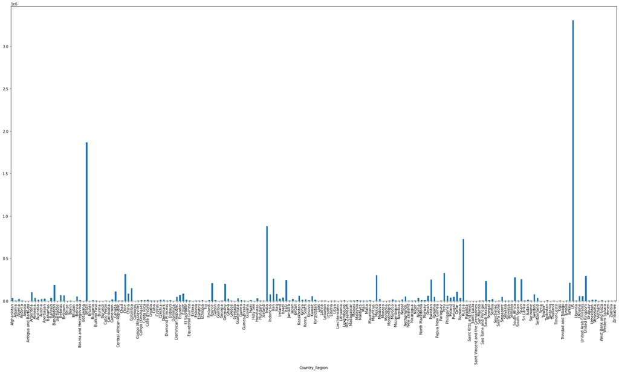

```python
confirm=countrywise_data.groupby('Country_Region').sum()['Confirmed']
confirm.plot(kind="bar",figsize=(30,15))
print(confirm)
```

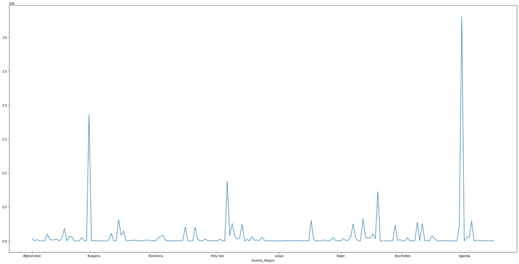

```python
confirm=countrywise_data.groupby('Country_Region').sum()['Confirmed']
confirm.plot(kind="line",figsize=(30,15))
```

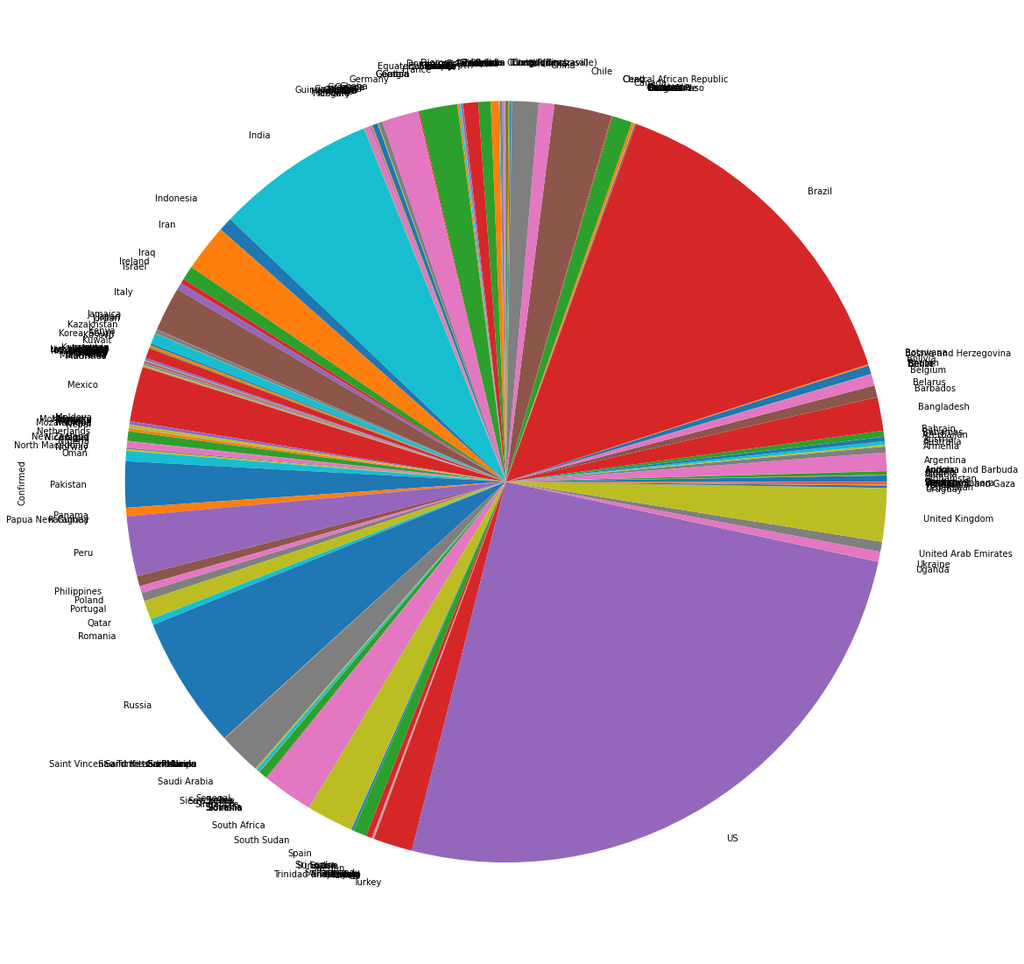

```python
confirm.plot(kind="pie",figsize=(35,20))
```

# **Though US has the highest number of deaths as we can see that in the graph below ,"UK" is standing 3rd though their number of confirmed cases are really less compared to "US" ,where as brazil in the 2nd place**

```
Country_Region
Afghanistan           1010
Albania                 93
Algeria               1011
Andorra                 52
Angola                  26
                      ...
West Bank and Gaza      36
Western Sahara           1
Yemen                  417
Zambia                  42
Zimbabwe                18
Name: Deaths, Length: 188, dtype: int64
```

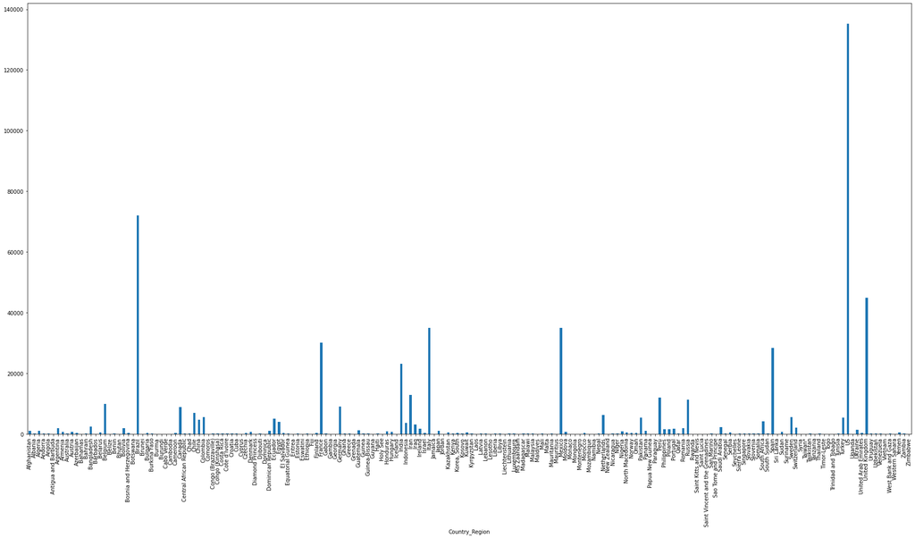

```python
deaths=countrywise_data.groupby('Country_Region').sum()['Deaths']
deaths.plot(kind="bar",figsize=(30,15))
print(deaths)
```

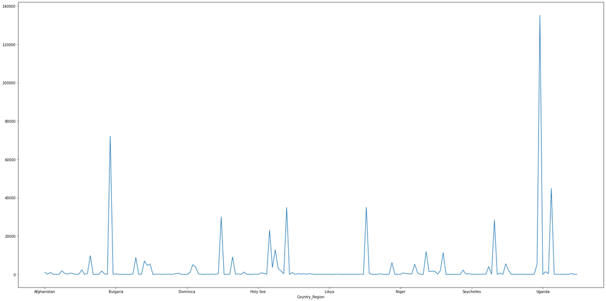

```python
deaths=countrywise_data.groupby('Country_Region').sum()['Deaths']
deaths.plot(kind="line",figsize=(30,15))
```

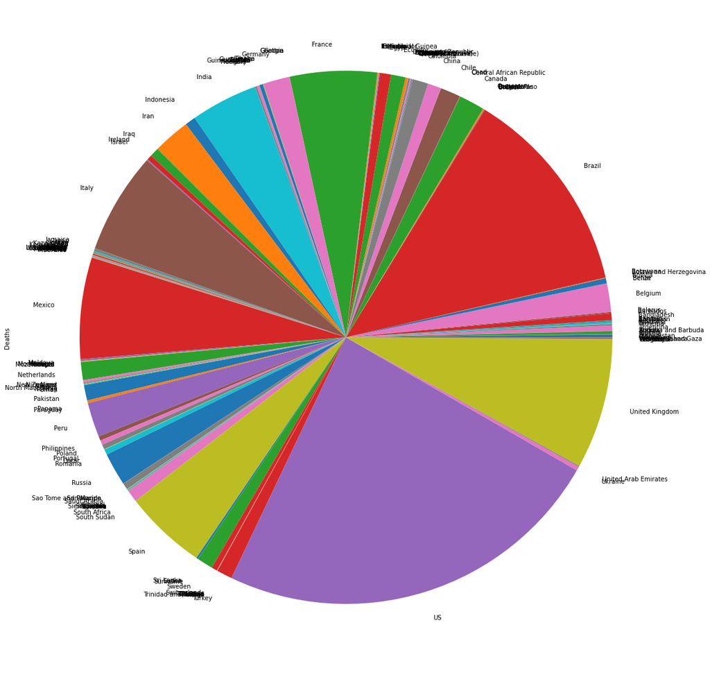

```python
deaths.plot(kind="pie",figsize=(30,20))
```

# Brazil has the highest number of recovered cases overall

```
Country_Region
Afghanistan           21216
Albania                1946
Algeria               13743
Andorra                 803
Angola                  118
                      ...
West Bank and Gaza      942
Western Sahara            8
Yemen                   659
Zambia                 1412
Zimbabwe                328
Name: Recovered, Length: 188, dtype: int64
```

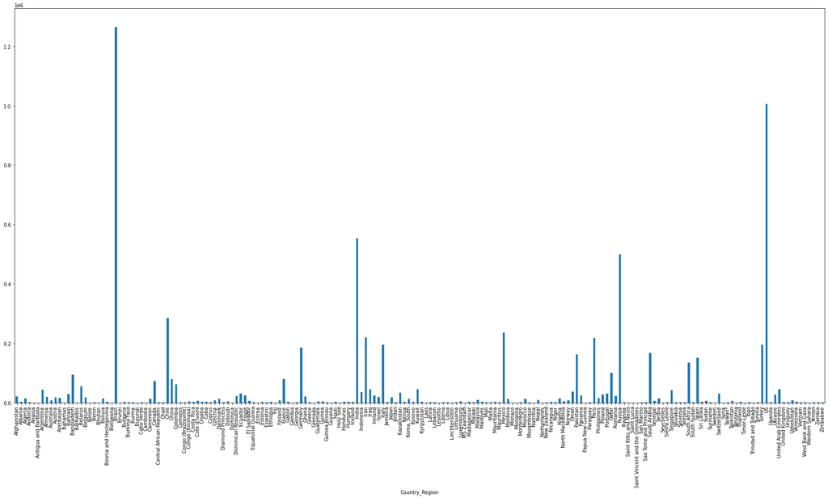

```python
recovered=countrywise_data.groupby('Country_Region').sum()['Recovered']
recovered.plot(kind="bar",figsize=(30,15))
print(recovered)
```

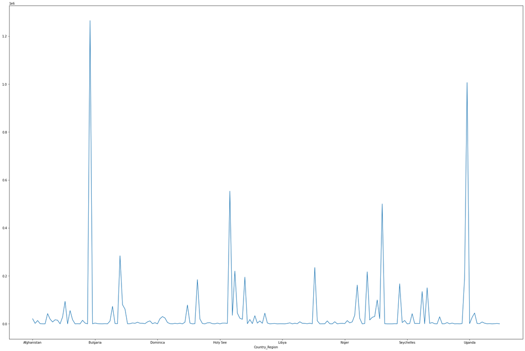

```python
recovered.plot(kind="line",figsize=(30,20))
```

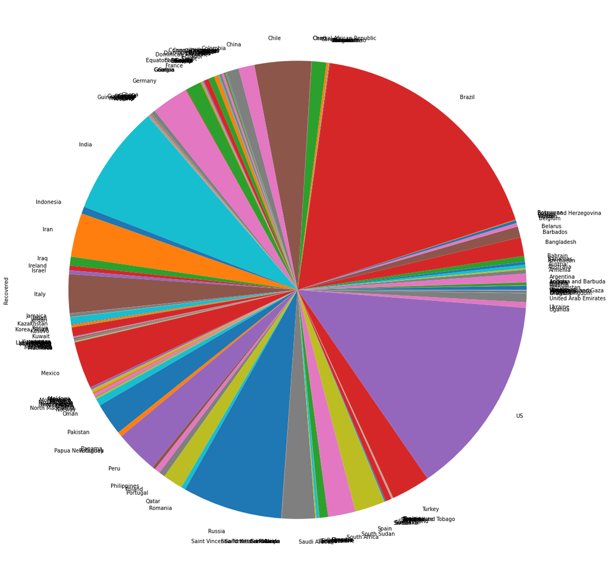

```python
recovered.plot(kind="pie",figsize=(30,20))
```

# Number of Active cases w.r.t to the country,after some of them being recoverd till the end date provided

```
Country_Region
Afghanistan           12225.0
Albania                1415.0
Algeria                4441.0
Andorra                   0.0
Angola                  362.0
                       ...
West Bank and Gaza     5252.0
Western Sahara            1.0
Yemen                   389.0
Zambia                  441.0
Zimbabwe                639.0
Name: Active, Length: 188, dtype: float64
```

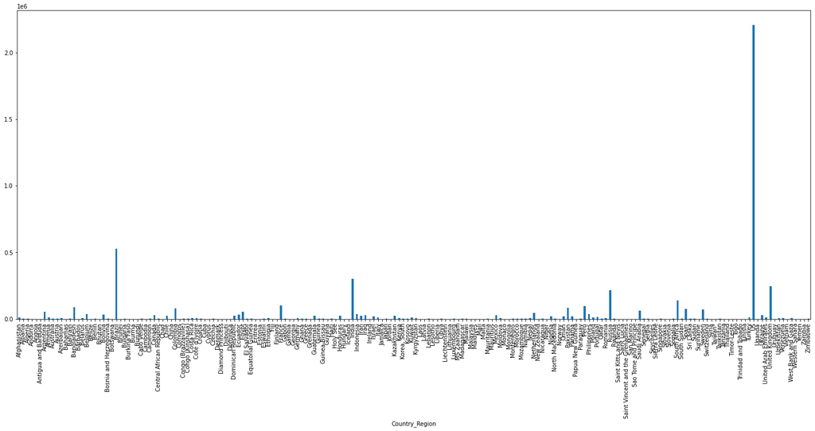

```python
A=countrywise_data.groupby('Country_Region').sum()['Active']
A.plot(kind="bar",figsize=(25,10))
print(A)
```

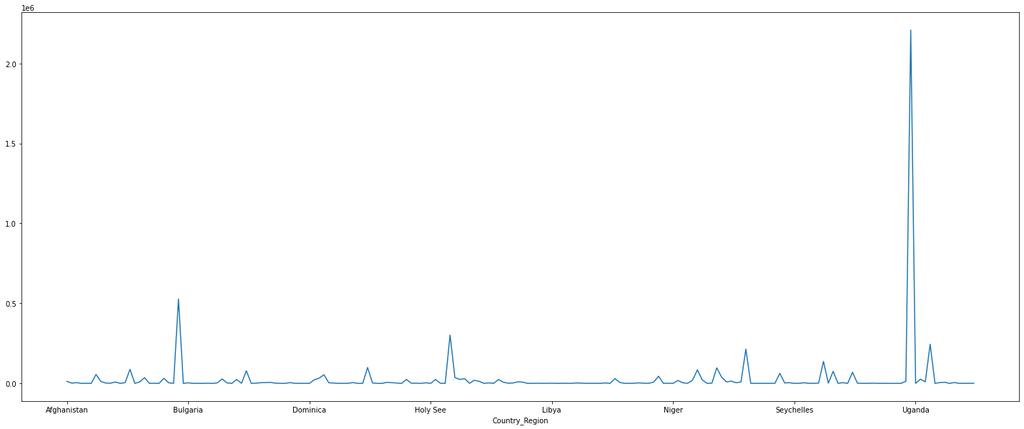

```python
A.plot(kind="line",figsize=(25,10))
```

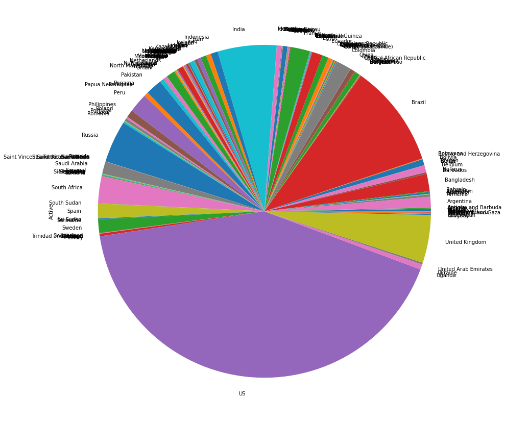

```python
A.plot(kind="pie",figsize=(30,15))
```

```python
rk=countrywise_data[['Country_Region','Confirmed','Deaths','Recovered']]   ##Confirmed	Deaths	Recovered
```

```python
rk.head()
```

|  | Country_Region | Confirmed | Deaths | Recovered |
| --- | --- | --- | --- | --- |
| 0 | US | 153 | 1 | 0 |
| 1 | US | 1339 | 45 | 0 |
| 2 | US | 1042 | 14 | 0 |
| 3 | US | 4146 | 25 | 0 |
| 4 | US | 17 | 0 | 0 |

```python
rk.Country_Region.value_counts()
```

```
US              3142
Russia            83
Japan             48
India             36
Colombia          34
                ...
Uzbekistan         1
Cyprus             1
Cuba               1
Ethiopia           1
Sierra Leone       1
Name: Country_Region, Length: 188, dtype: int64
```

```python
countrywise_data.head()
```

|  | FIPS | Admin2 | Province_State | Country_Region | Last_Update | Lat | Long_ | Confirmed | Deaths | Recovered | Active | Combined_Key | Incidence_Rate | Case-Fatality_Ratio |
| --- | --- | --- | --- | --- | --- | --- | --- | --- | --- | --- | --- | --- | --- | --- |
| 0 | 45001.0 | Abbeville | South Carolina | US | 2020-07-13 04:43:04 | 34.223334 | -82.461707 | 153 | 1 | 0 | 152.0 | Abbeville, South Carolina, US | 623.802340 | 0.653595 |
| 1 | 22001.0 | Acadia | Louisiana | US | 2020-07-13 04:43:04 | 30.295065 | -92.414197 | 1339 | 45 | 0 | 1294.0 | Acadia, Louisiana, US | 2158.111048 | 3.360717 |
| 2 | 51001.0 | Accomack | Virginia | US | 2020-07-13 04:43:04 | 37.767072 | -75.632346 | 1042 | 14 | 0 | 1028.0 | Accomack, Virginia, US | 3224.408962 | 1.343570 |
| 3 | 16001.0 | Ada | Idaho | US | 2020-07-13 04:43:04 | 43.452658 | -116.241552 | 4146 | 25 | 0 | 4121.0 | Ada, Idaho, US | 860.903637 | 0.602991 |
| 4 | 19001.0 | Adair | Iowa | US | 2020-07-13 04:43:04 | 41.330756 | -94.471059 | 17 | 0 | 0 | 17.0 | Adair, Iowa, US | 237.695749 | 0.000000 |

# Drawing insights from the country US

```python
us_confirmed=countrywise_data.query('Country_Region=="US" & Confirmed >=0').head()
```

```python
us_confirmed.tail()
```

|  | FIPS | Admin2 | Province_State | Country_Region | Last_Update | Lat | Long_ | Confirmed | Deaths | Recovered | Active | Combined_Key | Incidence_Rate | Case-Fatality_Ratio |
| --- | --- | --- | --- | --- | --- | --- | --- | --- | --- | --- | --- | --- | --- | --- |
| 0 | 45001.0 | Abbeville | South Carolina | US | 2020-07-13 04:43:04 | 34.223334 | -82.461707 | 153 | 1 | 0 | 152.0 | Abbeville, South Carolina, US | 623.802340 | 0.653595 |
| 1 | 22001.0 | Acadia | Louisiana | US | 2020-07-13 04:43:04 | 30.295065 | -92.414197 | 1339 | 45 | 0 | 1294.0 | Acadia, Louisiana, US | 2158.111048 | 3.360717 |
| 2 | 51001.0 | Accomack | Virginia | US | 2020-07-13 04:43:04 | 37.767072 | -75.632346 | 1042 | 14 | 0 | 1028.0 | Accomack, Virginia, US | 3224.408962 | 1.343570 |
| 3 | 16001.0 | Ada | Idaho | US | 2020-07-13 04:43:04 | 43.452658 | -116.241552 | 4146 | 25 | 0 | 4121.0 | Ada, Idaho, US | 860.903637 | 0.602991 |
| 4 | 19001.0 | Adair | Iowa | US | 2020-07-13 04:43:04 | 41.330756 | -94.471059 | 17 | 0 | 0 | 17.0 | Adair, Iowa, US | 237.695749 | 0.000000 |

```python
us_confirmed.isnull().sum()
```

```
FIPS                   0
Admin2                 0
Province_State         0
Country_Region         0
Last_Update            0
Lat                    0
Long_                  0
Confirmed              0
Deaths                 0
Recovered              0
Active                 0
Combined_Key           0
Incidence_Rate         0
Case-Fatality_Ratio    0
dtype: int64
```

## These are the "confirmed" cases till the provided date in the "US" alone where we can see the data of different states

```
Province_State
Idaho             4146
Iowa                17
Louisiana         1339
South Carolina     153
Virginia          1042
Name: Confirmed, dtype: int64
```

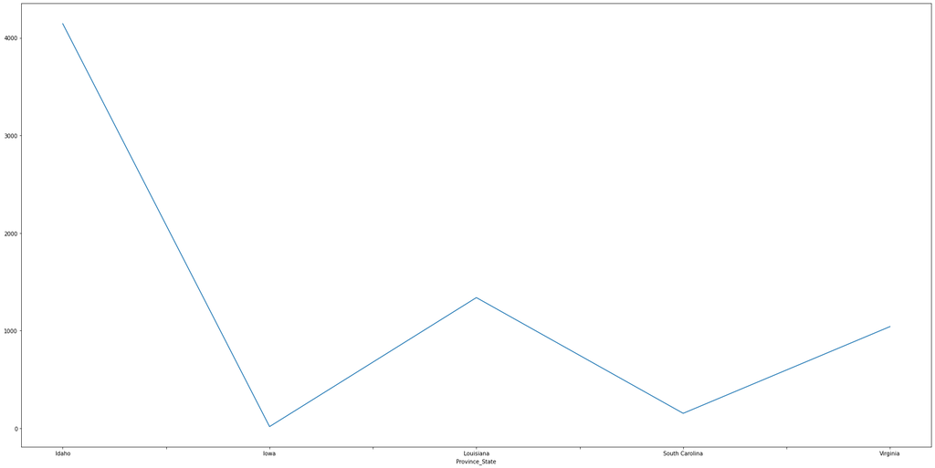

```python
us=us_confirmed.groupby('Province_State').sum()['Confirmed']
us.plot(kind="line",figsize=(30,15))
print(us)
```

```
Province_State
Idaho             4146
Iowa                17
Louisiana         1339
South Carolina     153
Virginia          1042
Name: Confirmed, dtype: int64
```

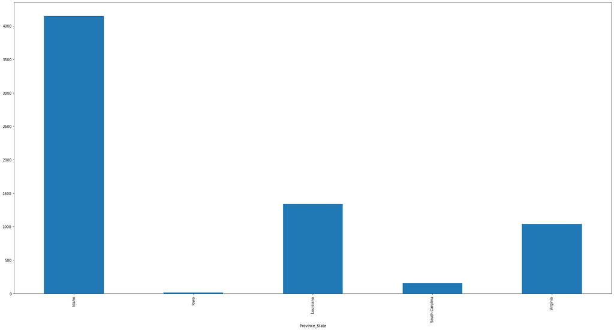

```python
us=us_confirmed.groupby('Province_State').sum()['Confirmed']
us.plot(kind="bar",figsize=(30,15))
print(us)
```

```
Province_State
Idaho             4146
Iowa                17
Louisiana         1339
South Carolina     153
Virginia          1042
Name: Confirmed, dtype: int64
```

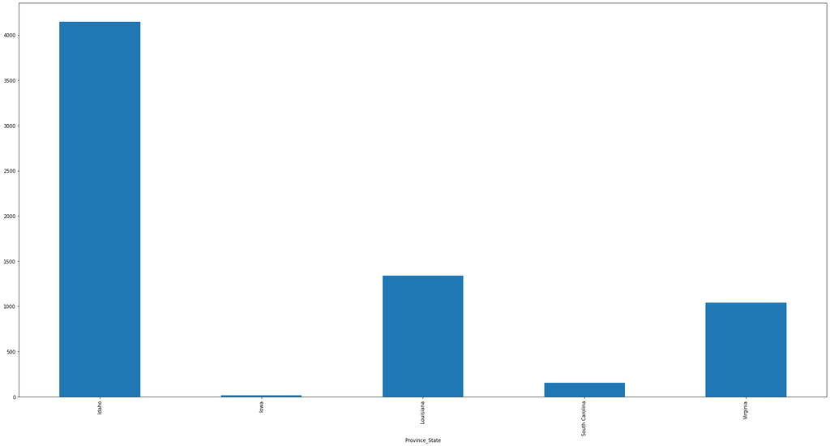

```python
us=us_confirmed.groupby('Province_State').sum()['Confirmed']
us.plot(kind="bar",figsize=(30,15))
print(us)
```

```
Province_State
Idaho             4146
Iowa                17
Louisiana         1339
South Carolina     153
Virginia          1042
Name: Confirmed, dtype: int64
```

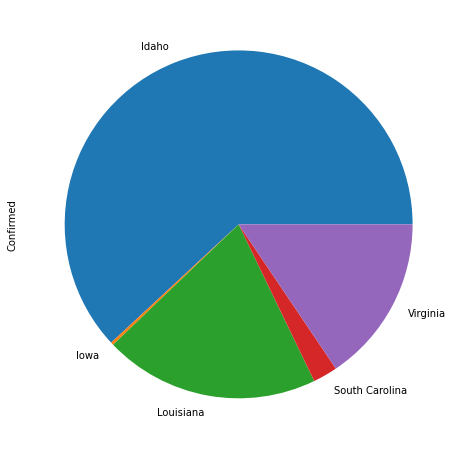

```python
us=us_confirmed.groupby('Province_State').sum()['Confirmed']
us.plot(kind="pie",figsize=(8,8))
print(us)
```

## Louisiana has recorded the highest number of deaths in our given data

```
Province_State
Idaho             25
Iowa               0
Louisiana         45
South Carolina     1
Virginia          14
Name: Deaths, dtype: int64
```

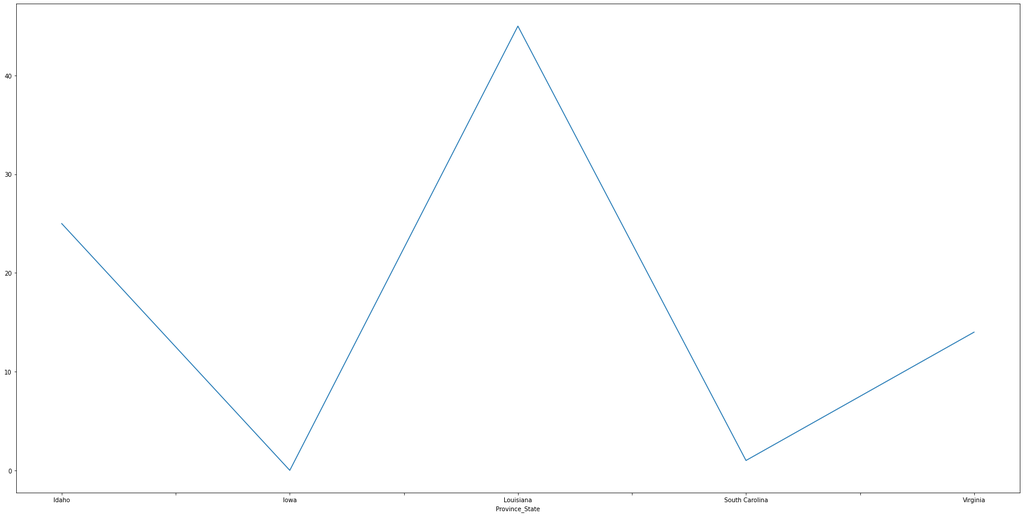

```python
us_d=us_confirmed.groupby('Province_State').sum()['Deaths']
us_d.plot(kind="line",figsize=(30,15))
print(us_d)
```

```
Province_State
Idaho             25
Iowa               0
Louisiana         45
South Carolina     1
Virginia          14
Name: Deaths, dtype: int64
```

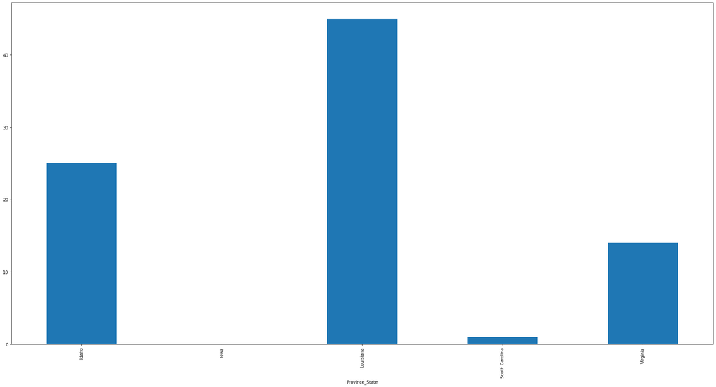

```python
us_d=us_confirmed.groupby('Province_State').sum()['Deaths']
us_d.plot(kind="bar",figsize=(30,15))
print(us_d)
```

```
Province_State
Idaho             25
Iowa               0
Louisiana         45
South Carolina     1
Virginia          14
Name: Deaths, dtype: int64
```

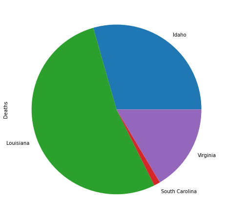

```python
us_d=us_confirmed.groupby('Province_State').sum()['Deaths']
us_d.plot(kind="pie",figsize=(8,8))
print(us_d)
```

## This is sadly interesting that none of the infected have been recovered in our given data in the "US"

```
Province_State
Idaho             0
Iowa              0
Louisiana         0
South Carolina    0
Virginia          0
Name: Recovered, dtype: int64
```

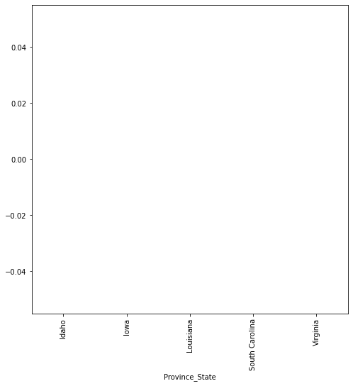

```python
us_r=us_confirmed.groupby('Province_State').sum()['Recovered']
us_r.plot(kind="bar",figsize=(8,8))
print(us_r)
```

# Active cases data in the country US till the end date provided

```
Province_State
Idaho             4121.0
Iowa                17.0
Louisiana         1294.0
South Carolina     152.0
Virginia          1028.0
Name: Active, dtype: float64
```

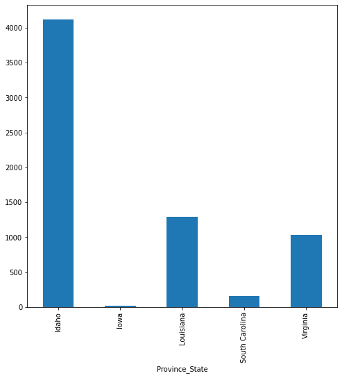

```python
us_a=us_confirmed.groupby('Province_State').sum()['Active']
us_a.plot(kind="bar",figsize=(8,8))
print(us_a)
```

```
Province_State
Idaho             4121.0
Iowa                17.0
Louisiana         1294.0
South Carolina     152.0
Virginia          1028.0
Name: Active, dtype: float64
```

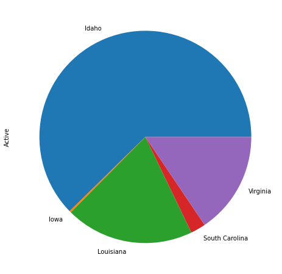

```python
us_a=us_confirmed.groupby('Province_State').sum()['Active']
us_a.plot(kind="pie",figsize=(8,8))
print(us_a)
```

```
Province_State
Idaho             4121.0
Iowa                17.0
Louisiana         1294.0
South Carolina     152.0
Virginia          1028.0
Name: Active, dtype: float64
```

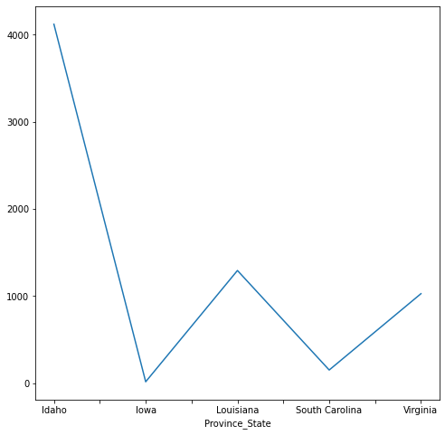

```python
us_a=us_confirmed.groupby('Province_State').sum()['Active']
us_a.plot(kind="line",figsize=(8,8))
print(us_a)
```

# Grabbing out the insights of confirmed ,recovered,deaths,active cases in INDIA

```python
India=countrywise_data.query('Country_Region=="India" & Confirmed >0').head()
```

```python
list(India['Province_State'].unique())
```

```
['Andaman and Nicobar Islands',
 'Andhra Pradesh',
 'Arunachal Pradesh',
 'Assam',
 'Bihar']
```

```python
India.head()
```

|  | FIPS | Admin2 | Province_State | Country_Region | Last_Update | Lat | Long_ | Confirmed | Deaths | Recovered | Active | Combined_Key | Incidence_Rate | Case-Fatality_Ratio |
| --- | --- | --- | --- | --- | --- | --- | --- | --- | --- | --- | --- | --- | --- | --- |
| 3150 | NaN | NaN | Andaman and Nicobar Islands | India | 2020-07-13 04:43:04 | 11.225999 | 92.968178 | 163 | 0 | 93 | 70.0 | Andaman and Nicobar Islands, India | 39.085355 | 0.000000 |
| 3151 | NaN | NaN | Andhra Pradesh | India | 2020-07-13 04:43:04 | 15.912900 | 79.740000 | 29168 | 328 | 15412 | 13428.0 | Andhra Pradesh, India | 54.111622 | 1.124520 |
| 3165 | NaN | NaN | Arunachal Pradesh | India | 2020-07-13 04:43:04 | 27.768456 | 96.384277 | 359 | 2 | 138 | 219.0 | Arunachal Pradesh, India | 22.859573 | 0.557103 |
| 3166 | NaN | NaN | Assam | India | 2020-07-13 04:43:04 | 26.357149 | 92.830441 | 16071 | 35 | 10426 | 5610.0 | Assam, India | 45.134334 | 0.217784 |
| 3188 | NaN | NaN | Bihar | India | 2020-07-13 04:43:04 | 25.679658 | 85.604840 | 16642 | 143 | 11498 | 5001.0 | Bihar, India | 13.334944 | 0.859272 |

# Andhra pradesh has recorded the highest number of cases which are confirmed till the end date and time

```
Province_State
Andaman and Nicobar Islands      163
Andhra Pradesh                 29168
Arunachal Pradesh                359
Assam                          16071
Bihar                          16642
Name: Confirmed, dtype: int64
```

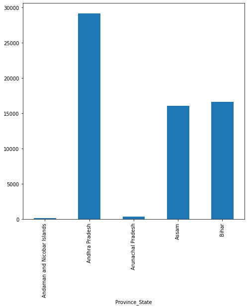

```python
ind_con=India.groupby('Province_State').sum()['Confirmed']
ind_con.plot(kind="bar",figsize=(8,8))
print(ind_con)
```

```
Province_State
Andaman and Nicobar Islands      163
Andhra Pradesh                 29168
Arunachal Pradesh                359
Assam                          16071
Bihar                          16642
Name: Confirmed, dtype: int64
```

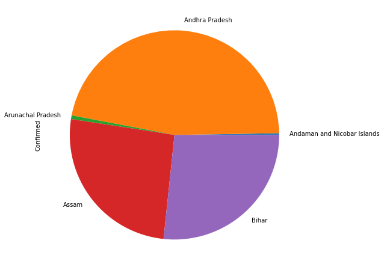

```python
ind_con=India.groupby('Province_State').sum()['Confirmed']
ind_con.plot(kind="pie",figsize=(8,8))
print(ind_con)
```

```
Province_State
Andaman and Nicobar Islands      163
Andhra Pradesh                 29168
Arunachal Pradesh                359
Assam                          16071
Bihar                          16642
Name: Confirmed, dtype: int64
```

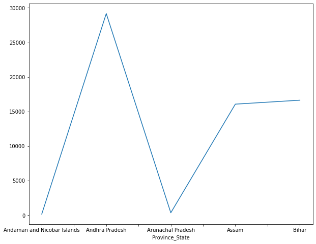

```python
ind_con=India.groupby('Province_State').sum()['Confirmed']
ind_con.plot(kind="line",figsize=(10,8))
print(ind_con)
```

## Andaman and Nicobar Islands has recorded the "zero" deaths for the given data

```
Province_State
Andaman and Nicobar Islands      0
Andhra Pradesh                 328
Arunachal Pradesh                2
Assam                           35
Bihar                          143
Name: Deaths, dtype: int64
```

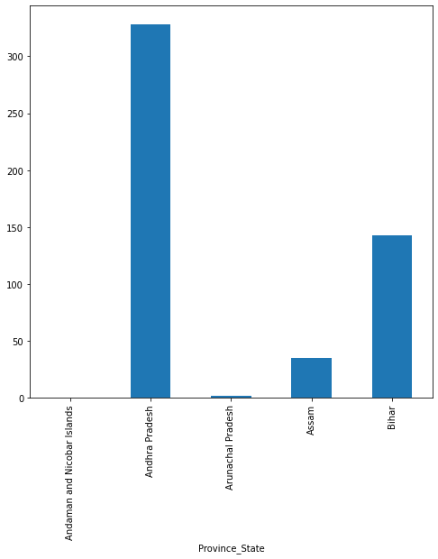

```python
ind_d=India.groupby('Province_State').sum()['Deaths']
ind_d.plot(kind="bar",figsize=(8,8))
print(ind_d)
```

```
Province_State
Andaman and Nicobar Islands      0
Andhra Pradesh                 328
Arunachal Pradesh                2
Assam                           35
Bihar                          143
Name: Deaths, dtype: int64
```

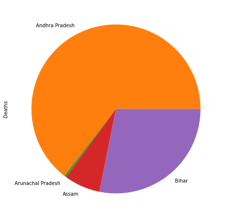

```python
ind_d=India.groupby('Province_State').sum()['Deaths']
ind_d.plot(kind="pie",figsize=(8,8))
print(ind_d)
```

```
Province_State
Andaman and Nicobar Islands      0
Andhra Pradesh                 328
Arunachal Pradesh                2
Assam                           35
Bihar                          143
Name: Deaths, dtype: int64
```

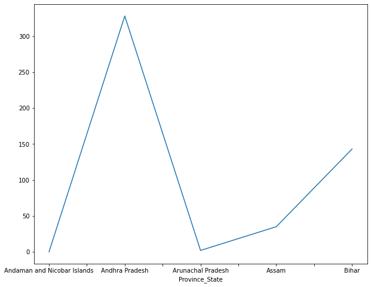

```python
ind_d=India.groupby('Province_State').sum()['Deaths']
ind_d.plot(kind="line",figsize=(10,8))
print(ind_d)
```

## **# Andhra Pradesh has been the highest amongst the cases recorded and also the number of victims recovered**

```
Province_State
Andaman and Nicobar Islands       93
Andhra Pradesh                 15412
Arunachal Pradesh                138
Assam                          10426
Bihar                          11498
Name: Recovered, dtype: int64
```

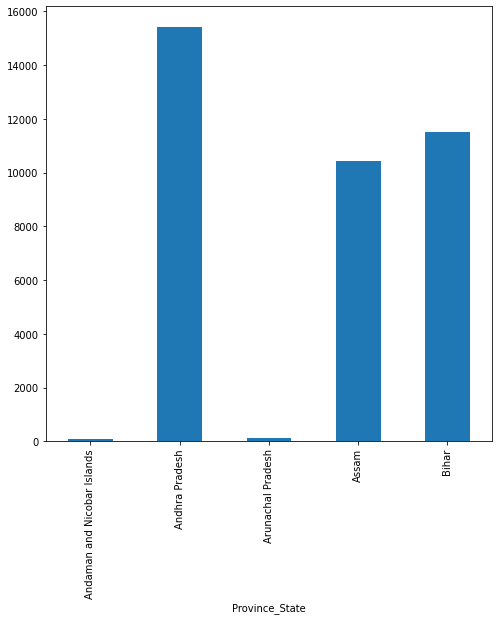

```python
ind_r=India.groupby('Province_State').sum()['Recovered']
ind_r.plot(kind="bar",figsize=(8,8))
print(ind_r)
```